# Automobile_Clustering

**Import Libraries**

```python
import numpy as np
import pandas as pd
import seaborn as sns
import matplotlib.pyplot as plt
%matplotlib inline
sns.set_theme(style='darkgrid',palette='deep')
import warnings as warn
warn.filterwarnings('ignore')
from scipy.stats import zscore
from sklearn.cluster import KMeans
from sklearn.metrics import silhouette_score
from scipy.cluster.hierarchy import cophenet,dendrogram,linkage
from scipy.spatial.distance import pdist
```

**Loading Dataset**

```python
#Loading dataset with car attributes
df1=pd.read_json('Part1 - Car-Attributes.json')

#Loading dataset with car names corresponding to the attributes
df2=pd.read_csv('Part1 - Car name.csv')

#final merging of the two datasets
df=pd.concat([df1,df2],join='outer',axis=1)

print('Size of dataframe : ',df.size )
print('Number of rows : ',df.shape[0])
print('Number of columms : ',df.shape[1])
```

```
Size of dataframe :  3582
Number of rows :  398
Number of columms :  9
```

**Exporting the final dataset for future use**

```python
df.to_csv('Automobile.csv',index=False) #As csv file
df.to_json('Automobile.json') # As json file
df.to_excel('Automobile.xlsx',index=False) # As Excel file
```

**Importing final data into python**

```python
auto=pd.read_csv('Automobile.csv')
auto.head()
```

|  | mpg | cyl | disp | hp | wt | acc | yr | origin | car_name |
| --- | --- | --- | --- | --- | --- | --- | --- | --- | --- |
| 0 | 18.0 | 8 | 307.0 | 130 | 3504 | 12.0 | 70 | 1 | chevrolet chevelle malibu |
| 1 | 15.0 | 8 | 350.0 | 165 | 3693 | 11.5 | 70 | 1 | buick skylark 320 |
| 2 | 18.0 | 8 | 318.0 | 150 | 3436 | 11.0 | 70 | 1 | plymouth satellite |
| 3 | 16.0 | 8 | 304.0 | 150 | 3433 | 12.0 | 70 | 1 | amc rebel sst |
| 4 | 17.0 | 8 | 302.0 | 140 | 3449 | 10.5 | 70 | 1 | ford torino |

**Renaming columns for better understanding**

```python
df.rename(columns={
    'mpg':'Miles_per_gallon',
    'cyl':'Cylinder',
    'disp':'displacement',
    'hp':'horsepower',
    'wt':'weight',
    'acc':'acceleration',
    'yr':'launchedyear',
},inplace=True)
```

**Data cleansing**

```python
df.isna().sum() #Checking for null values
```

```
Miles_per_gallon    0
Cylinder            0
displacement        0
horsepower          0
weight              0
acceleration        0
launchedyear        0
origin              0
car_name            0
dtype: int64
```

```python
df.info()
```

```
<class 'pandas.core.frame.DataFrame'>
RangeIndex: 398 entries, 0 to 397
Data columns (total 9 columns):
 #   Column            Non-Null Count  Dtype
---  ------            --------------  -----
 0   Miles_per_gallon  398 non-null    float64
 1   Cylinder          398 non-null    int64
 2   displacement      398 non-null    float64
 3   horsepower        398 non-null    object
 4   weight            398 non-null    int64
 5   acceleration      398 non-null    float64
 6   launchedyear      398 non-null    int64
 7   origin            398 non-null    int64
 8   car_name          398 non-null    object
dtypes: float64(3), int64(4), object(2)
memory usage: 28.1+ KB
```

**Checking for uneven data points within the dataset**

```python
for col in df.columns[:-1]:
  print(col)
  print(df[col].unique())
  print("\n\n")
```

```
Miles_per_gallon
[18.  15.  16.  17.  14.  24.  22.  21.  27.  26.  25.  10.  11.   9.
 28.  19.  12.  13.  23.  30.  31.  35.  20.  29.  32.  33.  17.5 15.5
 14.5 22.5 24.5 18.5 29.5 26.5 16.5 31.5 36.  25.5 33.5 20.5 30.5 21.5
 43.1 36.1 32.8 39.4 19.9 19.4 20.2 19.2 25.1 20.6 20.8 18.6 18.1 17.7
 27.5 27.2 30.9 21.1 23.2 23.8 23.9 20.3 21.6 16.2 19.8 22.3 17.6 18.2
 16.9 31.9 34.1 35.7 27.4 25.4 34.2 34.5 31.8 37.3 28.4 28.8 26.8 41.5
 38.1 32.1 37.2 26.4 24.3 19.1 34.3 29.8 31.3 37.  32.2 46.6 27.9 40.8
 44.3 43.4 36.4 44.6 40.9 33.8 32.7 23.7 23.6 32.4 26.6 25.8 23.5 39.1
 39.  35.1 32.3 37.7 34.7 34.4 29.9 33.7 32.9 31.6 28.1 30.7 24.2 22.4
 34.  38.  44. ]



Cylinder
[8 4 6 3 5]



displacement
[307.  350.  318.  304.  302.  429.  454.  440.  455.  390.  383.  340.
 400.  113.  198.  199.  200.   97.  110.  107.  104.  121.  360.  140.
  98.  232.  225.  250.  351.  258.  122.  116.   79.   88.   71.   72.
  91.   97.5  70.  120.   96.  108.  155.   68.  114.  156.   76.   83.
  90.  231.  262.  134.  119.  171.  115.  101.  305.   85.  130.  168.
 111.  260.  151.  146.   80.   78.  105.  131.  163.   89.  267.   86.
 183.  141.  173.  135.   81.  100.  145.  112.  181.  144. ]



horsepower
[130 165 150 140 198 220 215 225 190 170 160 95 97 85 88 46 87 90 113 200
 210 193 '?' 100 105 175 153 180 110 72 86 70 76 65 69 60 80 54 208 155
 112 92 145 137 158 167 94 107 230 49 75 91 122 67 83 78 52 61 93 148 129
 96 71 98 115 53 81 79 120 152 102 108 68 58 149 89 63 48 66 139 103 125
 133 138 135 142 77 62 132 84 64 74 116 82]



weight
```

[output cut: 32 more lines]

```
 14.9 17.7 15.3 13.9 12.8 15.4 17.6 22.2 22.1 14.2 17.4 16.2 17.8 12.2
 16.4 13.6 15.7 13.2 21.9 16.7 12.1 14.8 18.6 16.8 13.7 11.1 11.4 18.2
 15.8 15.9 14.1 21.5 14.4 19.4 19.2 17.2 18.7 15.1 13.4 11.2 14.7 16.6
 17.3 15.2 14.3 20.1 24.8 11.3 12.9 18.8 18.1 17.9 21.7 23.7 19.9 21.8
 13.8 12.6 16.1 20.7 18.3 20.4 19.6 17.1 15.6 24.6 11.6]



launchedyear
[70 71 72 73 74 75 76 77 78 79 80 81 82]



origin
[1 3 2]
```

Replacing the hp column containing uneven data with mode of the column, we can ultimately drop the rows but it is better to replace them with mode as this is the value which repeats itself the most.

```python
temp_hp=df[df['horsepower']!='?']['horsepower']
m=temp_hp.mode()
df['horsepower'].replace(to_replace='?',value=m[0],inplace=True)
df['horsepower'].unique()
```

```
array([130, 165, 150, 140, 198, 220, 215, 225, 190, 170, 160,  95,  97,
        85,  88,  46,  87,  90, 113, 200, 210, 193, 100, 105, 175, 153,
       180, 110,  72,  86,  70,  76,  65,  69,  60,  80,  54, 208, 155,
       112,  92, 145, 137, 158, 167,  94, 107, 230,  49,  75,  91, 122,
        67,  83,  78,  52,  61,  93, 148, 129,  96,  71,  98, 115,  53,
        81,  79, 120, 152, 102, 108,  68,  58, 149,  89,  63,  48,  66,
       139, 103, 125, 133, 138, 135, 142,  77,  62, 132,  84,  64,  74,
       116,  82], dtype=int64)
```

```python
#Saving two seperate copies of data for our analysis using.
df_for_K_means=df.copy()
df_for_Hierarchicy=df.copy()
```

```python
df.head()
```

|  | Miles_per_gallon | Cylinder | displacement | horsepower | weight | acceleration | launchedyear | origin | car_name |
| --- | --- | --- | --- | --- | --- | --- | --- | --- | --- |
| 0 | 18.0 | 8 | 307.0 | 130 | 3504 | 12.0 | 70 | 1 | chevrolet chevelle malibu |
| 1 | 15.0 | 8 | 350.0 | 165 | 3693 | 11.5 | 70 | 1 | buick skylark 320 |
| 2 | 18.0 | 8 | 318.0 | 150 | 3436 | 11.0 | 70 | 1 | plymouth satellite |
| 3 | 16.0 | 8 | 304.0 | 150 | 3433 | 12.0 | 70 | 1 | amc rebel sst |
| 4 | 17.0 | 8 | 302.0 | 140 | 3449 | 10.5 | 70 | 1 | ford torino |

**Data analysis & visualisation**

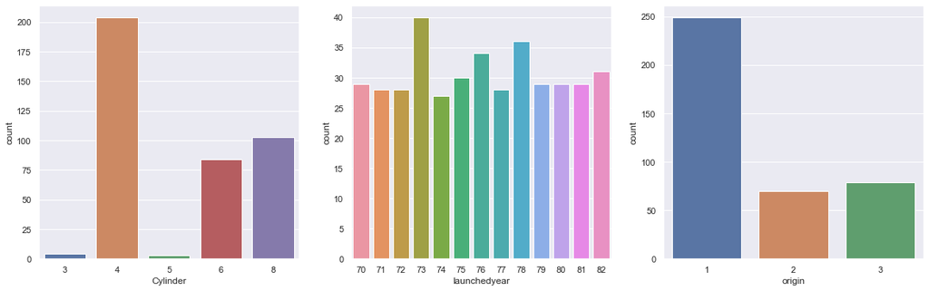

```python
#Analysing discrete columns
analysis_columns=['Cylinder','launchedyear','origin']
plt.figure(figsize=(20,20))
for i in range(0,len(analysis_columns)):
  plt.subplot(3,3,i+1)
  ax=sns.countplot(data=df,x=analysis_columns[i])
```

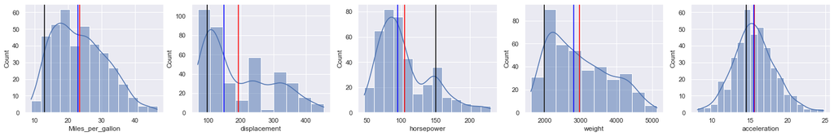

```python
#Analysis based on continuous data
cylinder_cols=['Miles_per_gallon','displacement','horsepower','weight','acceleration',]
plt.figure(figsize=(25,20))
for i in range(0,len(cylinder_cols)):
  plt.subplot(5,5,i+1)
  ax1=sns.histplot(data=df,x=cylinder_cols[i],kde=True)
  plt.axvline(df[cylinder_cols[i]].mean(),0,1,color='red')
  plt.axvline(df[cylinder_cols[i]].median(),0,1,color='blue')
  plt.axvline(df[cylinder_cols[i]].mode()[0],0,1,color='black')
```

**We can derive following conclusion from the conitnuous data**

- Miles per gallon distribution is right skewed, majority of the data is distributed towards mean and most occuring around 12.
- Distance distribution is right skewed, majority of the data is spread away from mean, most frequent distance covered is around 95.
- Horsepower is right skewed, There are roughly two peaks one of the peaks constitute the most of the frequent Horsepower as 150.
- Weight is right skewed.
- Acceleration is almost symetrically distributed.

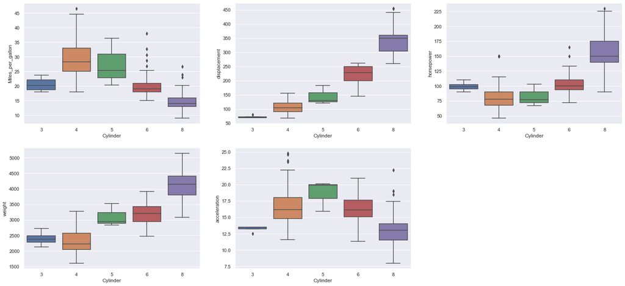

```python
#Analysis of discrete columns with respect to conitnuous values
plt.figure(figsize=(25,30))
cylinder_cols=['Miles_per_gallon','displacement','horsepower','weight','acceleration',]
for i in range(0,len(cylinder_cols)):
  plt.subplot(5,3,i+1)
  sns.boxplot(data=df,y=cylinder_cols[i],x='Cylinder',)
```

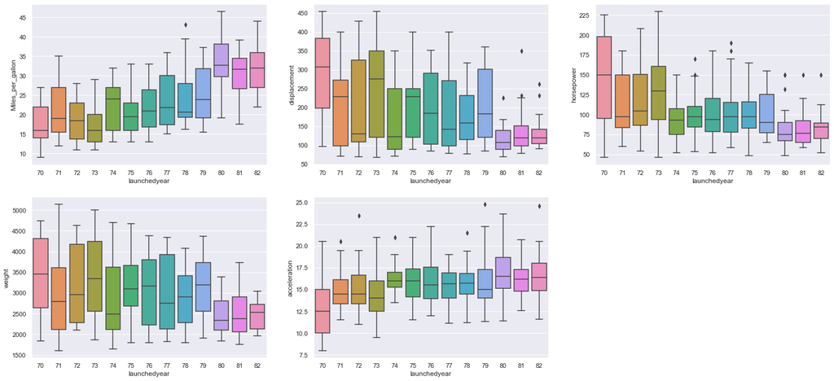

```python
#Analysis of discrete columns with respect to conitnuous values
plt.figure(figsize=(25,30))
cylinder_cols=['Miles_per_gallon','displacement','horsepower','weight','acceleration',]
for i in range(0,len(cylinder_cols)):
  plt.subplot(5,3,i+1)
  sns.boxplot(data=df,y=cylinder_cols[i],x='launchedyear',)
```

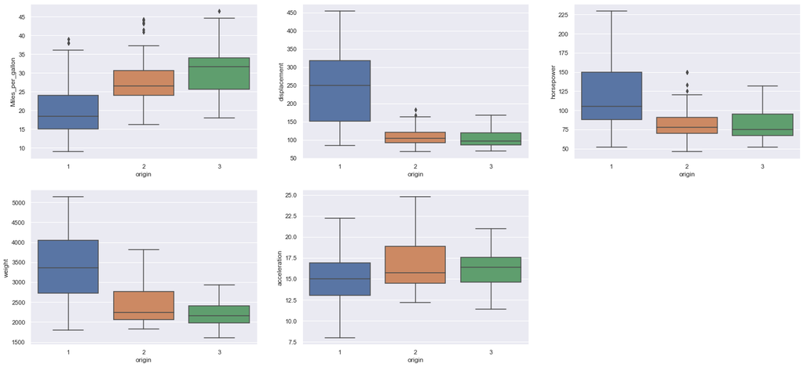

```python
#Analysis of discrete columns with respect to conitnuous values
plt.figure(figsize=(25,30))
cylinder_cols=['Miles_per_gallon','displacement','horsepower','weight','acceleration',]
for i in range(0,len(cylinder_cols)):
  plt.subplot(5,3,i+1)
  sns.boxplot(data=df,y=cylinder_cols[i],x='origin',)
```

```python
df.describe().transpose()
```

|  | count | mean | std | min | 25% | 50% | 75% | max |
| --- | --- | --- | --- | --- | --- | --- | --- | --- |
| Miles_per_gallon | 398.0 | 23.514573 | 7.815984 | 9.0 | 17.500 | 23.0 | 29.000 | 46.6 |
| Cylinder | 398.0 | 5.454774 | 1.701004 | 3.0 | 4.000 | 4.0 | 8.000 | 8.0 |
| displacement | 398.0 | 193.425879 | 104.269838 | 68.0 | 104.250 | 148.5 | 262.000 | 455.0 |
| horsepower | 398.0 | 105.155779 | 38.600986 | 46.0 | 76.000 | 95.0 | 130.000 | 230.0 |
| weight | 398.0 | 2970.424623 | 846.841774 | 1613.0 | 2223.750 | 2803.5 | 3608.000 | 5140.0 |
| acceleration | 398.0 | 15.568090 | 2.757689 | 8.0 | 13.825 | 15.5 | 17.175 | 24.8 |
| launchedyear | 398.0 | 76.010050 | 3.697627 | 70.0 | 73.000 | 76.0 | 79.000 | 82.0 |
| origin | 398.0 | 1.572864 | 0.802055 | 1.0 | 1.000 | 1.0 | 2.000 | 3.0 |

**Scaling**

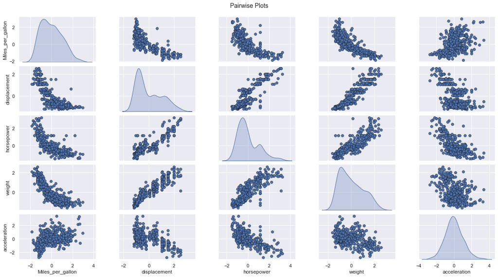

```python
cols = ['Miles_per_gallon','displacement','horsepower','weight','acceleration']
cardata=df[['Miles_per_gallon','Cylinder','displacement','horsepower','weight','acceleration','launchedyear','origin']]
carscaled=cardata.apply(zscore)
pp = sns.pairplot(carscaled[cols], height=1.8, aspect=1.8,
                  plot_kws=dict(edgecolor="k", linewidth=0.5),
                  diag_kind="kde", diag_kws=dict(shade=True));

fig = pp.fig
fig.subplots_adjust(top=0.93, wspace=0.3);
t = fig.suptitle('Pairwise Plots', fontsize=14);
```

**We can derive following conclusions :**

- We can take an estimate of what is the minimum number of clusters we get in the dataframe. For example.
- Displacement could contrirbute to minimum 3 groups to the final cluster.
- We can also notice a strong positive co-relation between weight and displacement and weight and horsepower.
- We can also notice that Miles per gallon is having negative correlation, with respect to displacement, horsepower and weight and it seems to only impact acceleration value.
- Increase in number of cylinders contribute to the increase in displacement,horsepower and weight and it also seems to bring down the average/Miles_per_gallon
- We can draw a heatmap and get an accurate value for the correlation among the variables.

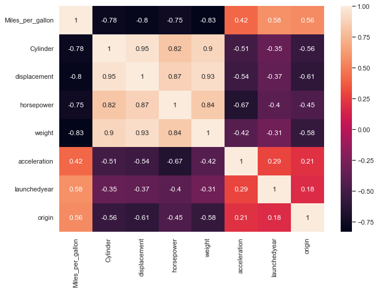

```python
#Corelation Analysis for
plt.figure(figsize=(10,7))
sns.heatmap(carscaled.corr(),fmt='.2g',annot=True);
```

**Analysis through K-Means**

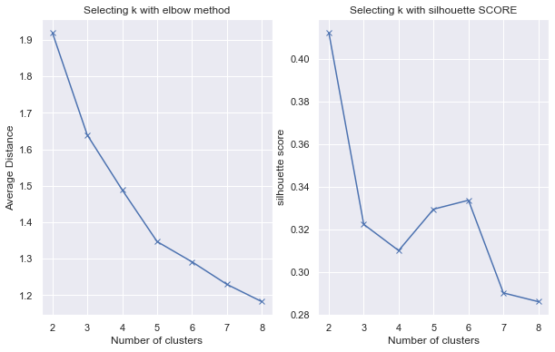

```python
#Finding optimal number of clusters
from scipy.spatial.distance import cdist #Calculating pairwaise distance between each pair of input points.
clusters=[2, 3, 4, 5, 6, 7, 8]
distortions=[]
silhouettes=[]
for k in clusters:
  model=KMeans(n_clusters=k)
  model.fit(carscaled)
  prediction=model.predict(carscaled)
  dist=cdist(carscaled,model.cluster_centers_,'euclidean') #Calculates the distance between centroid to each of the points.
  mindist=np.min(dist,axis=1) #Minimum distance between centroid to each point.
  distortions.append(sum(mindist)/carscaled.shape[0]) #Calculating Mean distortion

#Plotting for Mean cluster distance per cluster combination.

plt.figure(figsize=(10,6))
plt.subplot(1,2,1)
plt.plot(clusters,distortions,'bx-')
plt.xlabel('Number of clusters')
plt.ylabel('Average Distance')
plt.title('Selecting k with elbow method');

plt.subplot(1,2,2)
clusters=[2, 3, 4, 5, 6, 7, 8]
for k in clusters:
  model=KMeans(n_clusters=k)
  model.fit(carscaled)
  cluster_labels = model.labels_
  silhouettes.append(silhouette_score(carscaled,cluster_labels))

plt.plot(clusters,silhouettes,'bx-')
plt.xlabel('Number of clusters')
plt.ylabel('silhouette score')
plt.title('Selecting k with silhouette SCORE');
```

- From Elbow Method, we can say that the elbow is around 3,5.
- As Evident from the Pairplot we could easily picture that minimum groups that could be formed is around 3.
- For proper score calculation, we could pick up the silhoutte scores from corresponding clusters.

```
Cluster            0   1   2   3   4
Miles_per_gallon  72  94  81  84  67
Cylinder          72  94  81  84  67
displacement      72  94  81  84  67
horsepower        72  94  81  84  67
weight            72  94  81  84  67
acceleration      72  94  81  84  67
launchedyear      72  94  81  84  67
origin            72  94  81  84  67
car_name          72  94  81  84  67
```

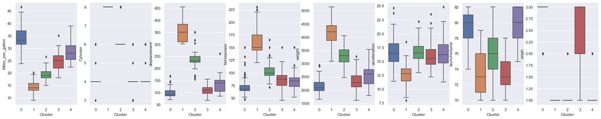

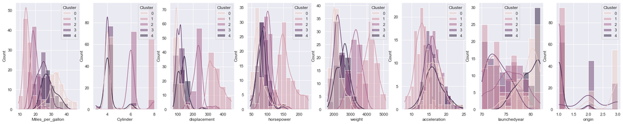

```python
# Making the model using k=5
final_model=KMeans(5)
final_model.fit(carscaled)
prediction=final_model.predict(carscaled)

#Adding the predicted values to the final dataset
df_for_K_means['Cluster']=prediction
car_clusters=df_for_K_means.groupby(['Cluster']);
print(car_clusters.count().transpose())
car_clusters.mean()

#Plotting for the graph
cols=['Miles_per_gallon','Cylinder','displacement','horsepower','weight','acceleration','launchedyear','origin']
plt.figure(figsize=(30,12))
for i in range(0,len(cols)):
  plt.subplot(2,8,i+1)
  sns.boxplot(data=df_for_K_means,y=cols[i],x='Cluster',)

cols=['Miles_per_gallon','Cylinder','displacement','horsepower','weight','acceleration','launchedyear','origin']
plt.figure(figsize=(30,12))
for i in range(0,len(cols)):
  plt.subplot(2,8,i+1)
  sns.histplot(data=df_for_K_means,x=cols[i],hue='Cluster',kde=True)
```

```python
#Dropping the Cluster column for analysis
df_for_K_means.drop('Cluster',axis=1,inplace=True)
```

```
Cluster             0    1    2
Miles_per_gallon  100  137  161
Cylinder          100  137  161
displacement      100  137  161
horsepower        100  137  161
weight            100  137  161
acceleration      100  137  161
launchedyear      100  137  161
origin            100  137  161
car_name          100  137  161
```

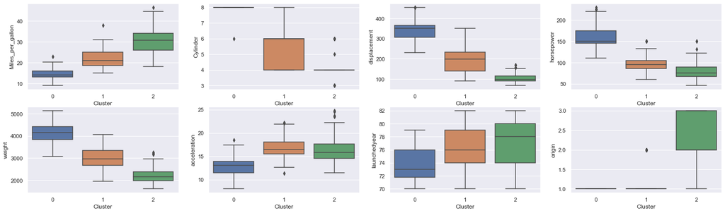

```python
# Making the model using k=3
final_model=KMeans(3)
final_model.fit(carscaled)
prediction=final_model.predict(carscaled)

#Adding the predicted values to the final dataset
df_for_K_means['Cluster']=prediction
car_clusters=df_for_K_means.groupby(['Cluster']);
print(car_clusters.count().transpose())
car_clusters.mean()

#Plotting for the graph
cols=['Miles_per_gallon','Cylinder','displacement','horsepower','weight','acceleration','launchedyear','origin']
plt.figure(figsize=(25,30))
for i in range(0,len(cols)):
  plt.subplot(8,4,i+1)
  sns.boxplot(data=df_for_K_means,y=cols[i],x='Cluster',)
```

**Following implications can be derived from 3 clusters**

- Cluster 2 seems to support more number of cars with around 25-35 range.
- Cluster 1 has dominating in the region of Cylinder capacity around 4 to a strong peak around 8 cylinders.
- Cluster 0 has relatively a larger displacement.
- Clusters 0 again has a higher horsepower.
- Cluster 0 has a higher weight as compared to other clusters.
- Cluster 1 has a slight more accleration as compared to cluster 2.
- Majority of cars in cluster 0 were launched in 72-76, cluster 1 in 74 to 79, cluster 2 in 74-80.
- Cluser 2 has a maximum origin of 2-3

```python
df_for_K_means.groupby("Cluster").count()
```

[output not shown]

**Analysis through Hierarchical clustering**

```python
#Since we have already scaled our data so we will directly use the scaled data
from sklearn.cluster import AgglomerativeClustering as Aggc
model=Aggc(n_clusters=3,linkage='average',affinity='euclidean')
model.fit(carscaled)
df_for_Hierarchicy['Labels']=model.labels_
```

```python
df_for_Hierarchicy.groupby("Labels").count()
```

| Labels | Miles_per_gallon | Cylinder | displacement | horsepower | weight | acceleration | launchedyear | origin | car_name |
| --- | --- | --- | --- | --- | --- | --- | --- | --- | --- |
| 0 | 218 | 218 | 218 | 218 | 218 | 218 | 218 | 218 | 218 |
| 1 | 80 | 80 | 80 | 80 | 80 | 80 | 80 | 80 | 80 |
| 2 | 100 | 100 | 100 | 100 | 100 | 100 | 100 | 100 | 100 |

**Analysis through Dendogram,Cophenetic index,Linkages**

```
0.6963811174183852
```

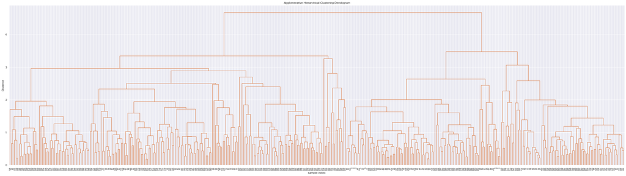

```python
z=linkage(carscaled,metric='euclidean',method='average')
c,dist=cophenet(z,pdist(carscaled))
print(c)
plt.figure(figsize=(35, 10))
plt.title('Agglomerative Hierarchical Clustering Dendogram')
plt.xlabel('sample index')
plt.ylabel('Distance')
dendrogram(z, leaf_rotation=90.,color_threshold = 40, leaf_font_size=8. )
plt.tight_layout()
```

```
0.7297518571846641
```

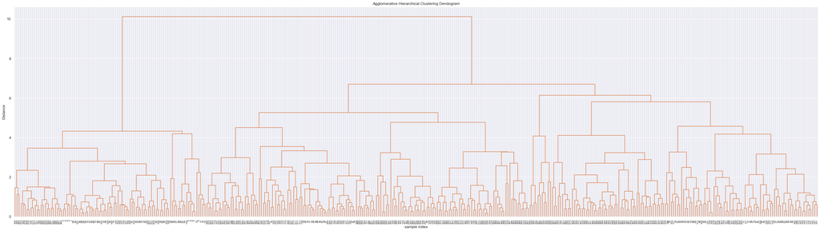

```python
z=linkage(carscaled,metric='euclidean',method='complete')
c,dist=cophenet(z,pdist(carscaled))
print(c)
plt.figure(figsize=(35, 10))
plt.title('Agglomerative Hierarchical Clustering Dendogram')
plt.xlabel('sample index')
plt.ylabel('Distance')
dendrogram(z, leaf_rotation=90.,color_threshold = 40, leaf_font_size=8. )
plt.tight_layout()
```

**Optimum number of clusters:**

- As we can see in both the cases, when we cut around 3 we see a clear 4 clusters in case of average method linkage.
- When we consider around 3 in case of complete linkage we can see very many clusters and the distance between each cluster is quite close so we can finally decide to cut around 6, we are getting 4 clusters. *Therefore we can reach our conclusion of getting 4 clusters from the Hierarchial clustering mechanism.

**Model generation**

```python
# importing library
from sklearn.linear_model import LinearRegression

# Normalise the dimensions for both the scenarios
x1=carscaled.copy()
yK=df_for_K_means['Cluster']
yH=df_for_Hierarchicy['Labels']

modelK=LinearRegression() #for K_means
modelH=LinearRegression() #for hierarachy

modelK.fit(x1,yK);
modelH.fit(x1,yH);

print("Score for K_Means Dataframe",modelK.score(x1,yK))
print("Score for Hierarchial Dataframe",modelH.score(x1,yH))

print("Coefficents for K_Means Dataframe :",modelK.coef_)
print("Coefficents for Hierarchial Dataframe: ",modelH.coef_)
```

```
Score for K_Means Dataframe 0.8877900831204767
Score for Hierarchial Dataframe 0.9604172145404499
Coefficents for K_Means Dataframe : [ 0.14205523 -0.24653749 -0.12421309 -0.15015992 -0.01108034 -0.02193816
 -0.02953897  0.20867407]
Coefficents for Hierarchial Dataframe:  [-0.05783335  0.70469773  0.03385812  0.01146368  0.02453932 -0.03159249
 -0.0210882   0.02335419]
```

**Improvements**

1. The dataset should have some more columns aswell like price so that there could be a better classification based on amount.
2. The dataset should consist of few more rows so that the insample data should learn more.